# MPDW Praktikum 6 dan 7 (Pendugaan Parameter, Diagnostik Model, dan Peramalan)

Windi Gunawan

2023-10-13

## Packages

```r
library(ggplot2)
library(tsibble)
library(tseries)
library(MASS)
library(forecast)
library(TSA)
library(TTR)
library(aTSA)
library(graphics)
```

## Data Asli

Digunakan data Lama Penyinaran Matahari Kota Bogor 2023 (SS) yang dalam hal ini digunakan data 115 periode

```r
library("rio")
data <- import("https://raw.githubusercontent.com/Windi82/MPDWP1/main/Data/Data%20MPDW_Lama%20penyinaran%20Matahari%20Kota%20Bogor%202023.csv")
datass <- data$ss
datass.ts<-ts(datass)
head(datass.ts)
```

```
## Time Series:
## Start = 1
## End = 6
## Frequency = 1
## [1] 6.1 4.1 7.5 4.8 5.5 7.2
```

```r
str(datass.ts)
```

```
##  Time-Series [1:115] from 1 to 115: 6.1 4.1 7.5 4.8 5.5 7.2 4.4 4.8 3.3 6.9 ...
```

### Eksplorasi Data

#### Plot Data Penuh

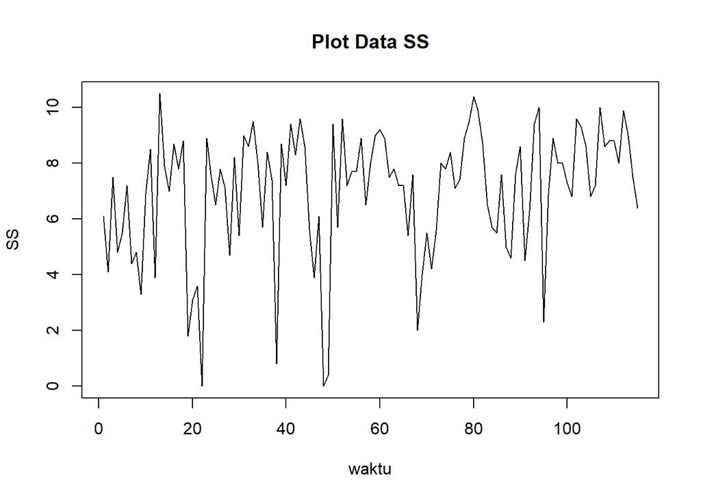

```r
plot.ts(datass.ts, lty=1, xlab="waktu", ylab="SS", main="Plot Data SS")
```

Berdasarkan plot data deret waktu di atas, terlihat data cenderung stasioner dalam rataan, namun tidak stasioner dalam ragam. Data stasioner dalam rataan karena menyebar/bergerak di sekitar nilai tengahnya dan tidak dikatakan stasioner dalam ragam karena memiliki lebar pita yang cenderung berbeda-beda. Selain dengan plot data deret waktu, akan dilakukan pengecekan stasioneritas data dengan plot ACF dan uji ADF.

### Membagi Data Latih dan Uji

Selanjutnya data dibagi berdasarkan pola data, pembagian data latih dan data uji ditetapkan dengan proporsi 80%:20% (92:23 data).

#### Plot Data Latih

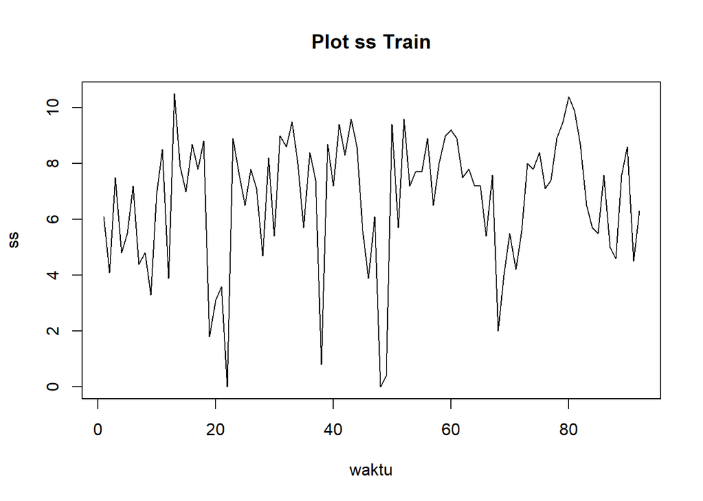

```r
sstrain<-datass[1:92]
train.ts<-ts(sstrain)
plot.ts(train.ts, lty=1, xlab="waktu", ylab="ss", main="Plot ss Train")
```

Berdasarkan plot data deret waktu pada data latih, terlihat bahwa data cenderung bergerak pada nilai tengah tertentu, hal itu berarti stasioner dalam rataan.

#### Plot Data Uji

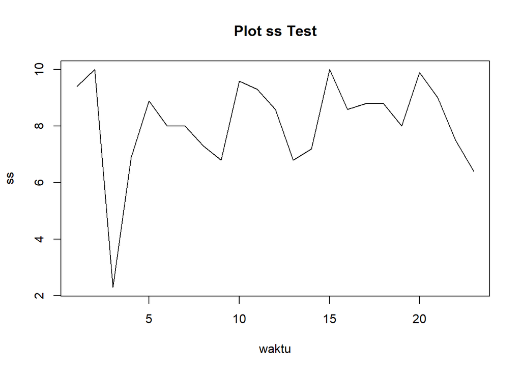

```r
sstest<-datass[93:115]
test.ts<-ts(sstest)
plot.ts(test.ts, lty=1, xlab="waktu", ylab="ss", main="Plot ss Test")
```

### Uji Stasioneritas Data

#### Plot ACF

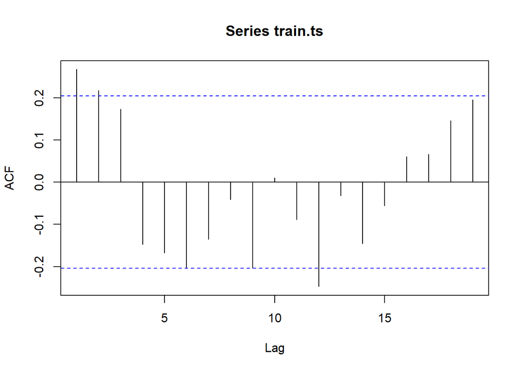

```r
acf(train.ts)
```

Berdasarkan plot ACF di atas, dapat dilihat bahwa plot *cuts off* pada *lag* ke-2. Hal ini sesuai dengan proses pembangkitan model MA(2).

#### Plot PACF

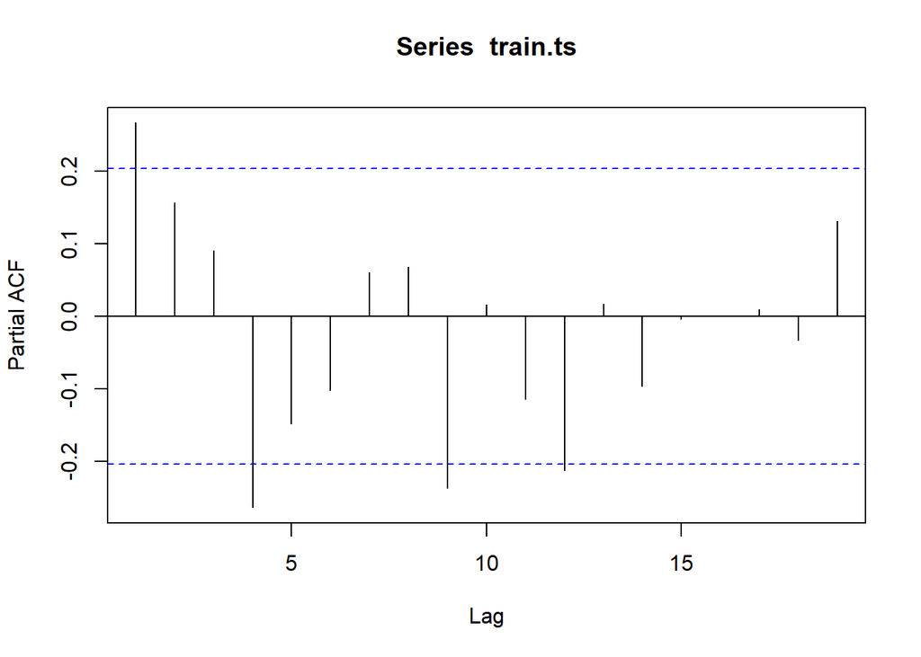

```r
pacf(train.ts)
```

Berdasarkan plot PACF di atas, dapat dilihat bahwa plot *cuts off* pada *lag* ke-1. Hal ini sesuai dengan proses pembangkitan model AR(1).

#### Uji ADF

```r
tseries::adf.test(train.ts)
```

```
##
##  Augmented Dickey-Fuller Test
##
## data:  train.ts
## Dickey-Fuller = -4.8509, Lag order = 4, p-value = 0.01
## alternative hypothesis: stationary
```

$H_0$ : Data tidak stasioner dalam rataan

$H_1$ : Data stasioner dalam rataan

Berdasarkan uji ADF tersebut, didapat *p-value* sebesar 0.01 yang lebih kecil dari taraf nyata 5% sehingga tolak $H_0$ dan menandakan bahwa data stasioner dalam rataan. Hal ini sesuai dengan hasil eksplorasi menggunakan plot time series dan plot ACF.

#### Plot Box-Cox

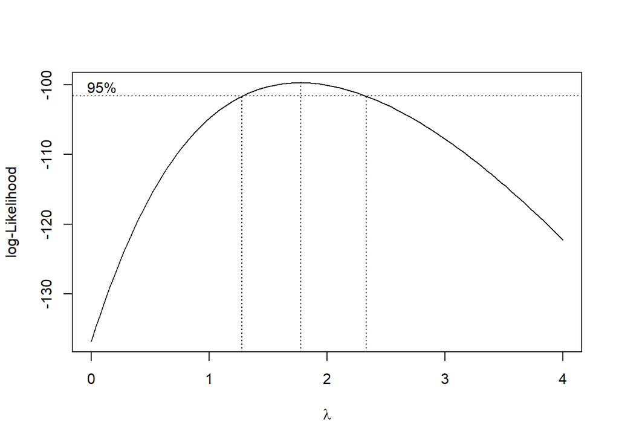

```r
library(MASS)
index <- seq(1:92)
for (i in index){
  train.ts[i]=train.ts[i]+1
} #Semua data ditambah satu karena ada yang bernilai 0
bc = boxcox(train.ts~index, lambda = seq(0,4,by=0.1))
```

```r
#Nilai Rounded Lambda
lambda <- bc$x[which.max(bc$y)]
lambda
```

```
## [1] 1.777778
```

```r
#SK
bc$x[bc$y > max(bc$y) - 1/2 * qchisq(.95,1)]
```

```
##  [1] 1.292929 1.333333 1.373737 1.414141 1.454545 1.494949 1.535354 1.575758
##  [9] 1.616162 1.656566 1.696970 1.737374 1.777778 1.818182 1.858586 1.898990
## [17] 1.939394 1.979798 2.020202 2.060606 2.101010 2.141414 2.181818 2.222222
## [25] 2.262626 2.303030
```

Plot Boxcox menunjukkan nilai *rounded value* ($\lambda$) optimum sebesar **1.777778** dan pada selang kepercayaan 95% nilai memiliki batas bawah **1.292929** dan batas atas **2.303030**. Selang tersebut tidak memuat nilai satu sehingga dapat dikatakan bahwa data tersebut tidak stasioner dalam ragam.

Karena data sudah stasioner dalam rataan maka langsung melakukan identifikasi model tanpa differencing.

### Identifikasi Model

#### Plot EACF

```r
eacf(train.ts)
```

```
## AR/MA
##   0 1 2 3 4 5 6 7 8 9 10 11 12 13
## 0 x x o o o o o o o o o  x  o  o
## 1 x o o o o o o o o o o  x  o  o
## 2 x o o o o o o o o o o  o  o  o
## 3 x x x o o o o o o o o  o  o  o
## 4 x o x o o o o o o o o  o  o  o
## 5 x o x o o o o o o o o  o  o  o
## 6 x x o o x o o o o o o  o  o  o
## 7 x x o o x o x o o o o  o  o  o
```

Identifikasi model menggunakan plot EACF dilakukan dengan melihat ujung segitiga pada pola segitiga nol. Dalam hal ini model tentatif yang terbentuk adalah ARIMA(0,0,2), ARIMA(1,0,1), ARIMA(2,0,1), ARIMA(3,0,3), dan ARIMA (4,0,3).

### Pendugaan Parameter Model Tentatif

#### ARIMA(0,0,2)

```r
model1.da=Arima(train.ts, order=c(0,0,2),method="ML")
summary(model1.da) #AIC=418.35
```

```
## Series: train.ts
## ARIMA(0,0,2) with non-zero mean
##
## Coefficients:
##         ma1     ma2    mean
##       0.153  0.1946  7.6966
## s.e.  0.115  0.1178  0.3148
##
## sigma^2 = 5.231:  log likelihood = -205.18
## AIC=418.35   AICc=418.81   BIC=428.44
##
## Training set error measures:
##                       ME     RMSE      MAE      MPE     MAPE     MASE
## Training set 0.005443219 2.249544 1.808198 -25.2039 43.99956 0.855229
##                    ACF1
## Training set 0.05004049
```

```r
lmtest::coeftest(model1.da) #terdapat parameter yang tidak signifikan
```

```
##
## z test of coefficients:
##
##           Estimate Std. Error z value Pr(>|z|)
## ma1        0.15303    0.11502  1.3305  0.18335
## ma2        0.19459    0.11776  1.6523  0.09847 .
## intercept  7.69662    0.31484 24.4464  < 2e-16 ***
## ---
## Signif. codes:  0 '***' 0.001 '**' 0.01 '*' 0.05 '.' 0.1 ' ' 1
```

#### ARIMA(1,0,1)

```r
model2.da=Arima(train.ts, order=c(1,0,1),method="ML")
summary(model2.da) #AIC=417.57
```

```
## Series: train.ts
## ARIMA(1,0,1) with non-zero mean
##
## Coefficients:
##          ar1      ma1    mean
##       0.5749  -0.3229  7.6958
## s.e.  0.1813   0.1956  0.3687
##
## sigma^2 = 5.186:  log likelihood = -204.79
## AIC=417.57   AICc=418.03   BIC=427.66
##
## Training set error measures:
##                       ME     RMSE      MAE       MPE     MAPE      MASE
## Training set 0.006554174 2.239916 1.747327 -24.34104 42.35674 0.8264382
##                     ACF1
## Training set -0.02876349
```

```r
lmtest::coeftest(model2.da) #terdapat parameter yang tidak signifikan
```

```
##
## z test of coefficients:
##
##           Estimate Std. Error z value  Pr(>|z|)
## ar1        0.57491    0.18132  3.1707  0.001521 **
## ma1       -0.32289    0.19562 -1.6506  0.098820 .
## intercept  7.69583    0.36867 20.8747 < 2.2e-16 ***
## ---
## Signif. codes:  0 '***' 0.001 '**' 0.01 '*' 0.05 '.' 0.1 ' ' 1
```

#### ARIMA(2,0,1)

```r
model3.da=Arima(train.ts, order=c(2,0,1),method="ML")
summary(model3.da) #AIC=418.78
```

```
## Series: train.ts
## ARIMA(2,0,1) with non-zero mean
##
## Coefficients:
##          ar1     ar2      ma1    mean
##       0.3356  0.1321  -0.1175  7.6895
## s.e.  0.2994  0.1306   0.2877  0.3816
##
## sigma^2 = 5.199:  log likelihood = -204.39
## AIC=418.78   AICc=419.48   BIC=431.39
##
## Training set error measures:
##                       ME     RMSE      MAE       MPE     MAPE      MASE
## Training set 0.008530572 2.230037 1.753541 -24.07882 42.26391 0.8293775
##                      ACF1
## Training set -0.002415505
```

```r
lmtest::coeftest(model3.da) #terdapat parameter yang tidak signifikan
```

```
##
## z test of coefficients:
##
##           Estimate Std. Error z value Pr(>|z|)
## ar1        0.33557    0.29935  1.1210   0.2623
## ar2        0.13207    0.13061  1.0112   0.3119
## ma1       -0.11749    0.28774 -0.4083   0.6830
## intercept  7.68945    0.38159 20.1509   <2e-16 ***
## ---
## Signif. codes:  0 '***' 0.001 '**' 0.01 '*' 0.05 '.' 0.1 ' ' 1
```

#### ARIMA(3,0,3)

```r
model4.da=Arima(train.ts, order=c(3,0,3),method="ML")
summary(model4.da) #AIC=416.04
```

```
## Series: train.ts
## ARIMA(3,0,3) with non-zero mean
##
## Coefficients:
##          ar1     ar2      ar3      ma1     ma2     ma3    mean
##       0.2441  0.0193  -0.2882  -0.0369  0.1865  0.5199  7.6996
## s.e.  0.3609  0.3682   0.3040   0.3320  0.3156  0.2359  0.3583
##
## sigma^2 = 4.871:  log likelihood = -200.02
## AIC=416.04   AICc=417.77   BIC=436.21
##
## Training set error measures:
##                       ME     RMSE      MAE       MPE    MAPE      MASE
## Training set 0.004226985 2.121435 1.640564 -21.36913 38.4108 0.7759422
##                    ACF1
## Training set -0.0158396
```

```r
lmtest::coeftest(model4.da) #terdapat parameter yang tidak signifikan
```

```
##
## z test of coefficients:
##
##            Estimate Std. Error z value Pr(>|z|)
## ar1        0.244118   0.360869  0.6765  0.49874
## ar2        0.019313   0.368160  0.0525  0.95816
## ar3       -0.288205   0.304024 -0.9480  0.34314
## ma1       -0.036861   0.331955 -0.1110  0.91158
## ma2        0.186498   0.315603  0.5909  0.55457
## ma3        0.519861   0.235857  2.2041  0.02751 *
## intercept  7.699609   0.358324 21.4878  < 2e-16 ***
## ---
## Signif. codes:  0 '***' 0.001 '**' 0.01 '*' 0.05 '.' 0.1 ' ' 1
```

#### ARIMA(4,0,3)

```r
model5.da=Arima(train.ts, order=c(4,0,3),method="ML")
summary(model5.da) #AIC=416.59
```

```
## Series: train.ts
## ARIMA(4,0,3) with non-zero mean
##
## Coefficients:
##          ar1      ar2      ar3      ar4      ma1     ma2     ma3    mean
##       0.5261  -0.0611  -0.0465  -0.2090  -0.3393  0.2017  0.2328  7.7018
## s.e.  0.4237   0.4337   0.3424   0.1513   0.4295  0.3724  0.3569  0.3042
##
## sigma^2 = 4.849:  log likelihood = -199.29
## AIC=416.59   AICc=418.78   BIC=439.28
##
## Training set error measures:
##                       ME     RMSE      MAE       MPE     MAPE      MASE
## Training set 0.001280216 2.104118 1.673933 -20.72783 38.12116 0.7917251
##                     ACF1
## Training set 0.000145775
```

```r
lmtest::coeftest(model5.da) #terdapat parameter yang tidak signifikan
```

```
##
## z test of coefficients:
##
##            Estimate Std. Error z value Pr(>|z|)
## ar1        0.526142   0.423710  1.2418   0.2143
## ar2       -0.061119   0.433734 -0.1409   0.8879
## ar3       -0.046487   0.342439 -0.1358   0.8920
## ar4       -0.208956   0.151343 -1.3807   0.1674
## ma1       -0.339268   0.429516 -0.7899   0.4296
## ma2        0.201655   0.372423  0.5415   0.5882
## ma3        0.232761   0.356942  0.6521   0.5143
## intercept  7.701809   0.304211 25.3174   <2e-16 ***
## ---
## Signif. codes:  0 '***' 0.001 '**' 0.01 '*' 0.05 '.' 0.1 ' ' 1
```

Berdasarkan pendugaan parameter di atas, tidak ada model yang semua parameternya signifikan.

## Alternatif

Karena data sudah stasioner dalam rataan maka seharusnya langsung melakukan identifikasi model, tidak differencing terlebih dahulu. Namun, saya tetap mencoba untuk melakukan differencing karena ketika tidak dilakukan differencing tidak terdapat model tentatif yang semua parameternya signifikan.

### Penanganan Ketidakstasioneran Data

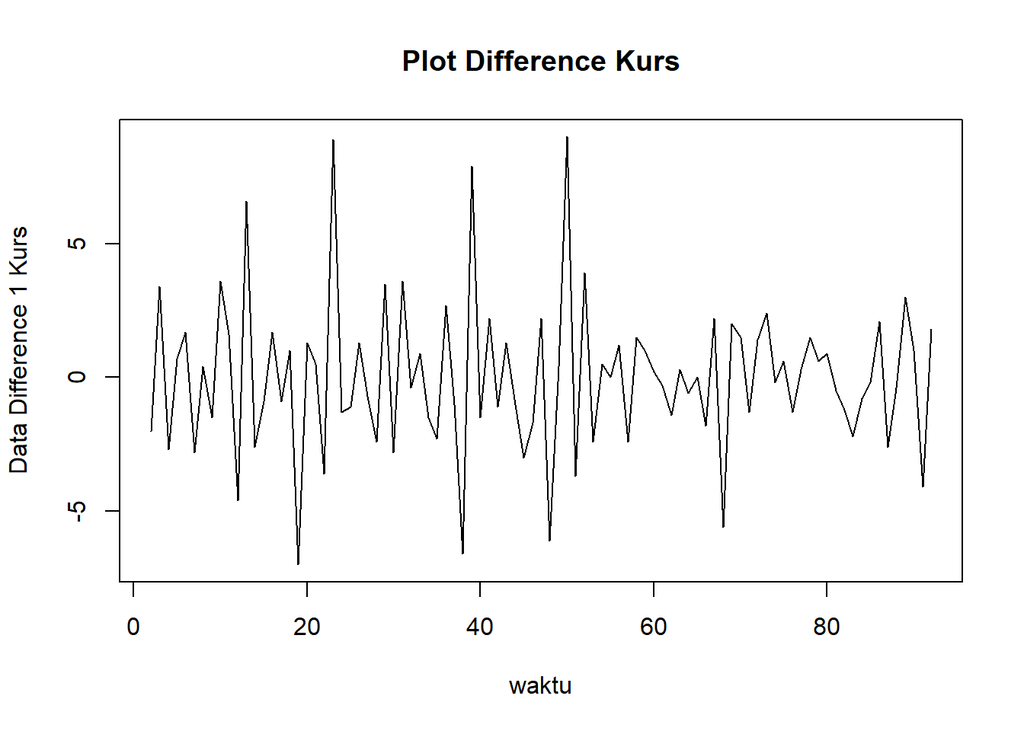

```r
## diferences
train.diff<-diff(train.ts,differences = 1)
plot.ts(train.diff, lty=1, xlab="waktu", ylab="Data Difference 1 Kurs", main="Plot Difference Kurs")
```

Berdasarkan plot data deret waktu, terlihat bahwa data stasioner dalam rataan ditandai dengan data bergerak pada nilai tengah tertentu (tidak terdapat trend ataupun musiman pada data)

#### Plot ACF

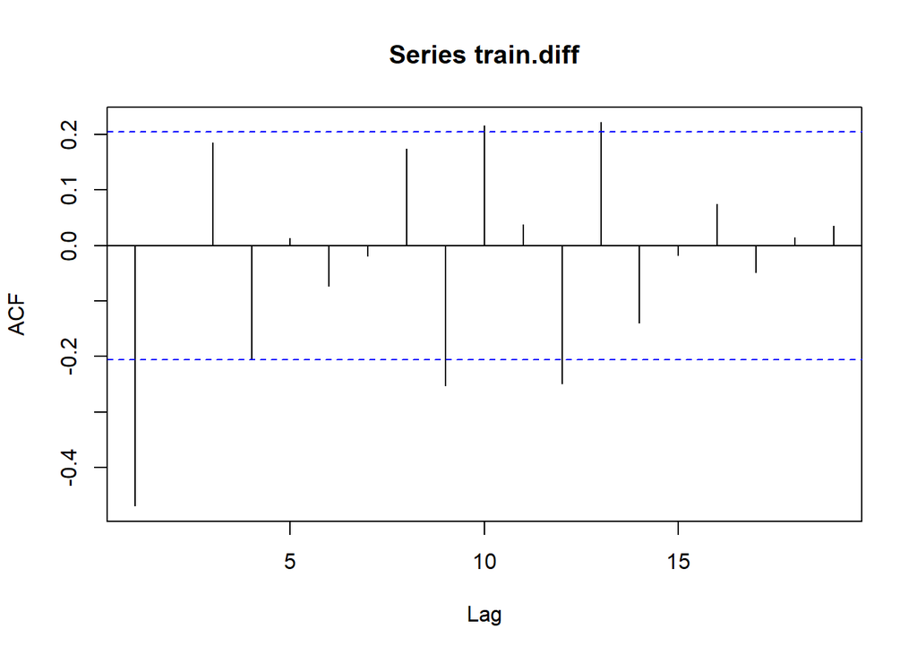

```r
acf(train.diff)
```

Berdasarkan plot tersebut, terlihat bahwa plot ACF *cuts off* pada *lag* ke 1. Hal ini menandakan data sudah stasioner dalam rataan.

#### Uji ADF

```r
tseries::adf.test(train.diff)
```

```
##
##  Augmented Dickey-Fuller Test
##
## data:  train.diff
## Dickey-Fuller = -5.4402, Lag order = 4, p-value = 0.01
## alternative hypothesis: stationary
```

$H_0$ : Data tidak stasioner dalam rataan

$H_1$ : Data stasioner dalam rataan

Berdasarkan uji ADF tersebut, didapat *p-value* sebesar 0.01 yang lebih kecil dari taraf nyata 5% sehingga tolak $H_0$ atau data stasioner dalam rataan. Hal ini sesuai dengan hasil eksplorasi menggunakan plot time series dan plot ACF.

### Identifikasi Model

#### Plot ACF

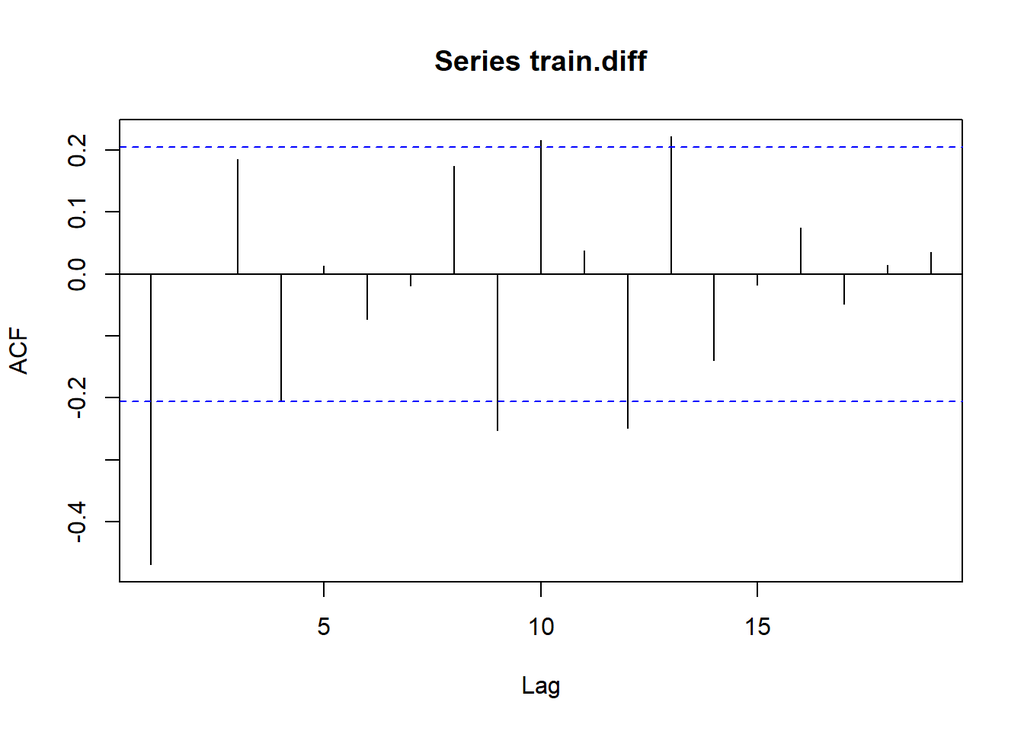

```r
acf(train.diff)
```

Berdasarkan plot tersebut, terlihat bahwa plot ACF cenderung *cuts off* pada lag ke 1, sehingga jika plot PACF dianggap *tails of*, maka model tentatifnya adalah ARIMA(0,1,1).

#### Plot PACF

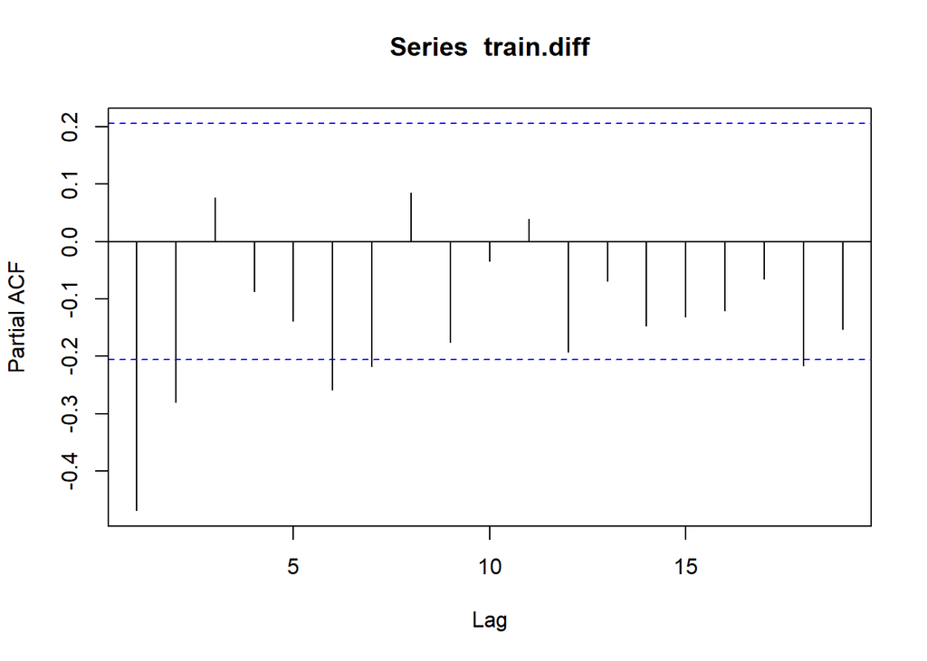

```r
pacf(train.diff)
```

Berdasarkan plot tersebut, terlihat bahwa plot PACF cenderung *cuts off* pada *lag* ke 2, sehingga jika plot ACF dianggap *tails of*, maka model tentatifnya adalah ARIMA(2,1,0).

Jika baik plot ACF maupun plot PACF keduanya dianggap tails of, maka model yang terbentuk adalah ARIMA(2,1,1)

#### Plot EACF

```r
eacf(train.diff)
```

```
## AR/MA
##   0 1 2 3 4 5 6 7 8 9 10 11 12 13
## 0 x o o o o o o o x o o  x  o  o
## 1 x o o o o o o o o o o  o  o  o
## 2 x o x o o o o o o o o  o  o  o
## 3 x o o o o o o o o o o  o  o  o
## 4 x o o o o o o o o o o  o  o  o
## 5 x o o o x o o o o o o  o  o  o
## 6 x x o o x o x o o o o  o  o  o
## 7 x o x o o o x o o o o  o  o  o
```

Identifikasi model menggunakan plot EACF dilakukan dengan melihat ujung segitiga pada pola segitiga nol. Dalam hal ini model tentatif yang terbentuk adalah ARIMA(0,1,1), ARIMA(1,1,1), ARIMA(2,1,1), ARIMA(2,1,3), ARIMA(3,1,1), ARIMA(4,1,1), dan ARIMA (5,1,1).

### Pendugaan Parameter Model Tentatif

#### ARIMA(0,1,1)

```r
model1.da=Arima(train.diff, order=c(0,1,1),method="ML")
summary(model1.da) #AIC=453.78
```

```
## Series: train.diff
## ARIMA(0,1,1)
##
## Coefficients:
##           ma1
##       -1.0000
## s.e.   0.0276
##
## sigma^2 = 8.338:  log likelihood = -224.89
## AIC=453.78   AICc=453.92   BIC=458.78
##
## Training set error measures:
##                      ME     RMSE      MAE  MPE MAPE      MASE       ACF1
## Training set 0.01927113 2.855571 2.107075 -Inf  Inf 0.5597308 -0.4618164
```

```r
lmtest::coeftest(model1.da) #semua parameter signifikan
```

```
##
## z test of coefficients:
##
##      Estimate Std. Error z value  Pr(>|z|)
## ma1 -0.999999   0.027581 -36.257 < 2.2e-16 ***
## ---
## Signif. codes:  0 '***' 0.001 '**' 0.01 '*' 0.05 '.' 0.1 ' ' 1
```

#### ARIMA(1,1,1)

```r
model2.da=Arima(train.diff, order=c(1,1,1),method="ML")
summary(model2.da) #AIC=434.2
```

```
## Series: train.diff
## ARIMA(1,1,1)
##
## Coefficients:
##           ar1      ma1
##       -0.4624  -1.0000
## s.e.   0.0929   0.0288
##
## sigma^2 = 6.561:  log likelihood = -214.1
## AIC=434.2   AICc=434.48   BIC=441.7
##
## Training set error measures:
##                       ME     RMSE      MAE MPE MAPE      MASE       ACF1
## Training set -0.03537943 2.518943 1.851998 NaN  Inf 0.4919712 -0.1296686
```

```r
lmtest::coeftest(model2.da) #semua parameter signifikan
```

```
##
## z test of coefficients:
##
##      Estimate Std. Error  z value  Pr(>|z|)
## ar1 -0.462418   0.092890  -4.9781 6.421e-07 ***
## ma1 -0.999999   0.028773 -34.7551 < 2.2e-16 ***
## ---
## Signif. codes:  0 '***' 0.001 '**' 0.01 '*' 0.05 '.' 0.1 ' ' 1
```

#### ARIMA(2,1,1)

```r
model3.da=Arima(train.diff, order=c(2,1,1),method="ML")
summary(model3.da) #AIC=429.6
```

```
## Series: train.diff
## ARIMA(2,1,1)
##
## Coefficients:
##           ar1      ar2      ma1
##       -0.5876  -0.2690  -1.0000
## s.e.   0.1011   0.1023   0.0296
##
## sigma^2 = 6.125:  log likelihood = -210.8
## AIC=429.6   AICc=430.07   BIC=439.6
##
## Training set error measures:
##                       ME     RMSE      MAE  MPE MAPE      MASE       ACF1
## Training set -0.02718063 2.419947 1.804646 -Inf  Inf 0.4793924 0.01349012
```

```r
lmtest::coeftest(model3.da) #semua parameter signifikan
```

```
##
## z test of coefficients:
##
##      Estimate Std. Error  z value  Pr(>|z|)
## ar1 -0.587599   0.101142  -5.8096 6.261e-09 ***
## ar2 -0.269015   0.102326  -2.6290  0.008563 **
## ma1 -0.999998   0.029589 -33.7963 < 2.2e-16 ***
## ---
## Signif. codes:  0 '***' 0.001 '**' 0.01 '*' 0.05 '.' 0.1 ' ' 1
```

#### ARIMA(2,1,3)

```r
model4.da=Arima(train.diff, order=c(2,1,3),method="ML")
summary(model4.da) #AIC=432.62
```

```
## Series: train.diff
## ARIMA(2,1,3)
##
## Coefficients:
##           ar1      ar2      ma1      ma2      ma3
##       -0.9069  -0.4311  -0.6481  -0.3307  -0.0213
## s.e.   0.2921   0.1814   0.3120   0.4141   0.2329
##
## sigma^2 = 6.211:  log likelihood = -210.31
## AIC=432.62   AICc=433.64   BIC=447.62
##
## Training set error measures:
##                       ME     RMSE      MAE  MPE MAPE      MASE        ACF1
## Training set -0.02601006 2.408651 1.820051 -Inf  Inf 0.4834845 -0.01139546
```

```r
lmtest::coeftest(model4.da) #terdapat parameter yang tidak signifikan
```

```
##
## z test of coefficients:
##
##      Estimate Std. Error z value Pr(>|z|)
## ar1 -0.906852   0.292075 -3.1049 0.001904 **
## ar2 -0.431051   0.181366 -2.3767 0.017469 *
## ma1 -0.648081   0.312036 -2.0769 0.037807 *
## ma2 -0.330653   0.414095 -0.7985 0.424583
## ma3 -0.021266   0.232903 -0.0913 0.927246
## ---
## Signif. codes:  0 '***' 0.001 '**' 0.01 '*' 0.05 '.' 0.1 ' ' 1
```

#### ARIMA(3,1,1)

```r
model5.da=Arima(train.diff, order=c(3,1,1),method="ML")
summary(model5.da) #AIC=430.84
```

```
## Series: train.diff
## ARIMA(3,1,1)
##
## Coefficients:
##           ar1      ar2     ar3      ma1
##       -0.5607  -0.2132  0.0933  -1.0000
## s.e.   0.1054   0.1203  0.1063   0.0293
##
## sigma^2 = 6.156:  log likelihood = -210.42
## AIC=430.84   AICc=431.55   BIC=443.33
##
## Training set error measures:
##                      ME    RMSE     MAE  MPE MAPE      MASE         ACF1
## Training set -0.0249244 2.41194 1.81884 -Inf  Inf 0.4831629 -0.003744501
```

```r
lmtest::coeftest(model5.da) #terdapat parameter yang tidak signifikan
```

```
##
## z test of coefficients:
##
##      Estimate Std. Error  z value  Pr(>|z|)
## ar1 -0.560739   0.105402  -5.3200 1.038e-07 ***
## ar2 -0.213241   0.120306  -1.7725   0.07631 .
## ar3  0.093288   0.106307   0.8775   0.38019
## ma1 -0.999995   0.029273 -34.1614 < 2.2e-16 ***
## ---
## Signif. codes:  0 '***' 0.001 '**' 0.01 '*' 0.05 '.' 0.1 ' ' 1
```

#### ARIMA(4,1,1)

```r
model6.da=Arima(train.diff, order=c(4,1,1),method="ML")
summary(model6.da) #AIC=432.27
```

```
## Series: train.diff
## ARIMA(4,1,1)
##
## Coefficients:
##           ar1      ar2     ar3      ar4      ma1
##       -0.5549  -0.2316  0.0473  -0.0801  -1.0000
## s.e.   0.1052   0.1222  0.1220   0.1061   0.0296
##
## sigma^2 = 6.177:  log likelihood = -210.13
## AIC=432.27   AICc=433.28   BIC=447.27
##
## Training set error measures:
##                       ME    RMSE      MAE  MPE MAPE      MASE        ACF1
## Training set -0.02880691 2.40195 1.819253 -Inf  Inf 0.4832726 -0.02129979
```

```r
lmtest::coeftest(model6.da) #terdapat parameter yang tidak signifikan
```

```
##
## z test of coefficients:
##
##     Estimate Std. Error  z value  Pr(>|z|)
## ar1 -0.55493    0.10518  -5.2763 1.319e-07 ***
## ar2 -0.23161    0.12223  -1.8949    0.0581 .
## ar3  0.04731    0.12198   0.3878    0.6981
## ar4 -0.08005    0.10606  -0.7548    0.4504
## ma1 -1.00000    0.02958 -33.8066 < 2.2e-16 ***
## ---
## Signif. codes:  0 '***' 0.001 '**' 0.01 '*' 0.05 '.' 0.1 ' ' 1
```

#### ARIMA(5,1,1)

```r
model7.da=Arima(train.diff, order=c(5,1,1),method="ML")
summary(model7.da) #AIC=432.71
```

```
## Series: train.diff
## ARIMA(5,1,1)
##
## Coefficients:
##           ar1      ar2     ar3      ar4      ar5      ma1
##       -0.5681  -0.2287  0.0141  -0.1560  -0.1323  -1.0000
## s.e.   0.1044   0.1208  0.1233   0.1207   0.1052   0.0302
##
## sigma^2 = 6.119:  log likelihood = -209.35
## AIC=432.71   AICc=434.07   BIC=450.21
##
## Training set error measures:
##                       ME     RMSE      MAE MPE MAPE      MASE        ACF1
## Training set -0.03273999 2.376682 1.786572 NaN  Inf 0.4745912 -0.04329903
```

```r
lmtest::coeftest(model7.da) #terdapat parameter yang tidak signifikan
```

```
##
## z test of coefficients:
##
##      Estimate Std. Error  z value  Pr(>|z|)
## ar1 -0.568119   0.104390  -5.4423  5.26e-08 ***
## ar2 -0.228716   0.120797  -1.8934   0.05831 .
## ar3  0.014124   0.123299   0.1145   0.90880
## ar4 -0.155959   0.120749  -1.2916   0.19650
## ar5 -0.132337   0.105168  -1.2583   0.20827
## ma1 -1.000000   0.030217 -33.0939 < 2.2e-16 ***
## ---
## Signif. codes:  0 '***' 0.001 '**' 0.01 '*' 0.05 '.' 0.1 ' ' 1
```

Berdasarkan pendugaan parameter di atas, model yang semua parameternya signifikan hanya model ARIMA(0,1,1), ARIMA(1,1,1), dan ARIMA(2,1,1). Dari ketiga model tersebut nilai AIC terkecil dimiliki oleh model ARIMA(2,1,1). Sehingga yang dipilih adalah model ARIMA(2,1,1) karena seluruh parameternya signifikan dengan AIC terkecil yaitu sebesar 429.6.

### Analisis Sisaan

Model terbaik hasil identifikasi kemudian dicek asumsi sisaannya. Sisaan model ARIMA harus memenuhi asumsi normalitas, kebebasan sisaan, dan kehomogenan ragam. Diagnostik model dilakukan secara eksplorasi dan uji formal.

#### Eksplorasi Sisaan

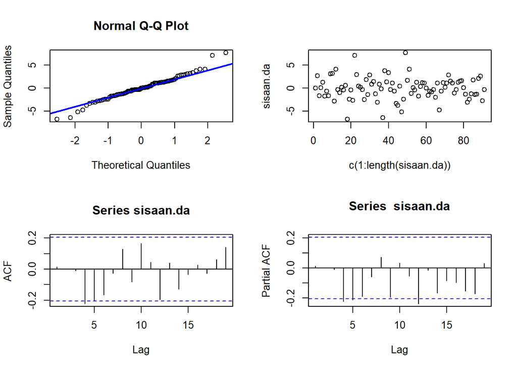

```r
#Eksplorasi
sisaan.da <- model3.da$residuals
par(mfrow=c(2,2))
qqnorm(sisaan.da)
qqline(sisaan.da, col = "blue", lwd = 2)
plot(c(1:length(sisaan.da)),sisaan.da)
acf(sisaan.da)
pacf(sisaan.da)
```

```r
par(mfrow = c(1,1))
```

#### Uji Formal

```r
#1) Sisaan Menyebar Normal
ks.test(sisaan.da,"pnorm")  #tak tolak H0 > sisaan menyebar normal
```

```
##
##  Exact one-sample Kolmogorov-Smirnov test
##
## data:  sisaan.da
## D = 0.20737, p-value = 0.0006553
## alternative hypothesis: two-sided
```

Selain dengan eksplorasi, asumsi tersebut dapat diuji menggunakan uji formal. Pada tahapan ini uji formal yang digunakan untuk normalitas adalah uji Kolmogorov-Smirnov (KS). Hipotesis pada uji KS adalah sebagai berikut.

$H_0$ : Sisaan menyebar normal

$H_1$ : Sisaan tidak menyebar normal

Berdasarkan uji KS tersebut, didapat *p-value* sebesar 0.0006553 yang kurang dari taraf nyata 5% sehingga tolak $H_0$ dan menandakan bahwa sisaan tidak menyebar normal. Hal ini sesuai dengan hasil eksplorasi menggunakan plot kuantil-kuantil normal.

```r
#2) Sisaan saling bebas/tidak ada autokorelasi
Box.test(sisaan.da, type = "Ljung")  #tak tolak H0 > sisaan saling bebas
```

```
##
##  Box-Ljung test
##
## data:  sisaan.da
## X-squared = 0.017113, df = 1, p-value = 0.8959
```

Selanjutnya akan dilakukan uji formal untuk kebebasan sisaan menggunakan uji Ljung-Box. Hipotesis yang digunakan adalah sebagai berikut.

$H_0$ : Sisaan saling bebas

$H_1$ : Sisaan tidak tidak saling bebas

Berdasarkan uji Ljung-Box tersebut, didapat *p-value* sebesar 0.8959 yang lebih besar dari taraf nyata 5% sehingga tak tolak $H_0$ dan menandakan bahwa sisaan saling bebas.

```r
#3) Sisaan homogen
Box.test((sisaan.da)^2, type = "Ljung")  #tak tolak H0 > sisaan homogen
```

```
##
##  Box-Ljung test
##
## data:  (sisaan.da)^2
## X-squared = 0.042801, df = 1, p-value = 0.8361
```

Hipotesis yang digunakan untuk uji kehomogenan ragam adalah sebagai berikut.

$H_0$ : Ragam sisaan homogen

$H_1$ : Ragam sisaan tidak homogen

Berdasarkan uji Ljung-Box terhadap sisaan kuadrat tersebut, didapat *p-value* sebesar 0.8361 yang lebih besar dari taraf nyata 5% sehingga tak tolak $H_0$ dan menandakan bahwa ragam sisaan homogen.

```r
#4) Nilai tengah sisaan sama dengan nol
t.test(sisaan.da, mu = 0, conf.level = 0.95)  #tak tolak h0 > nilai tengah sisaan sama dengan 0
```

```
##
##  One Sample t-test
##
## data:  sisaan.da
## t = -0.10656, df = 90, p-value = 0.9154
## alternative hypothesis: true mean is not equal to 0
## 95 percent confidence interval:
##  -0.5339191  0.4795578
## sample estimates:
##   mean of x
## -0.02718063
```

Terakhir, dengan uji-t, akan dicek apakah nilai tengah sisaan sama dengan nol. Hipotesis yang diujikan sebagai berikut.

$H_0$ : nilai tengah sisaan sama dengan 0

$H_1$ : nilai tengah sisaan tidak sama dengan 0

Berdasarkan uji-ttersebut, didapat *p-value* sebesar 0.9154 yang lebih besar dari taraf nyata 5% sehingga tak tolak $H_0$ dan menandakan bahwa nilai tengah sisaan sama dengan nol.

### Overfitting

Tahapan selanjutnya adalah *overfitting* dilakukan dengan menaikkan orde AR(p) dan MA(q) dari model ARIMA(2,1,1) untuk melihat apakah terdapat model lain yang lebih baik dari model saat ini. Kandidat model *overfitting* adalah ARIMA(2,1,2) dan ARIMA(3,1,1).

```r
#---OVERFITTING---#
model1a.ma2=Arima(train.diff, order=c(2,1,2),method="ML")
summary(model1a.ma2) #AIC=430.63
```

```
## Series: train.diff
## ARIMA(2,1,2)
##
## Coefficients:
##           ar1      ar2      ma1      ma2
##       -0.9122  -0.4197  -0.6454  -0.3546
## s.e.   0.2715   0.1343   0.2941   0.2928
##
## sigma^2 = 6.138:  log likelihood = -210.32
## AIC=430.63   AICc=431.35   BIC=443.13
##
## Training set error measures:
##                       ME     RMSE      MAE  MPE MAPE      MASE         ACF1
## Training set -0.02624718 2.408486 1.818934 -Inf  Inf 0.4831878 -0.009449432
```

```r
lmtest::coeftest(model1a.ma2) #ma2 tidak signifikan
```

```
##
## z test of coefficients:
##
##     Estimate Std. Error z value  Pr(>|z|)
## ar1 -0.91224    0.27154 -3.3595 0.0007808 ***
## ar2 -0.41973    0.13434 -3.1245 0.0017811 **
## ma1 -0.64539    0.29406 -2.1948 0.0281809 *
## ma2 -0.35461    0.29277 -1.2112 0.2258143
## ---
## Signif. codes:  0 '***' 0.001 '**' 0.01 '*' 0.05 '.' 0.1 ' ' 1
```

```r
model1b.ar3=Arima(train.diff, order=c(3,1,1),method="ML")
summary(model1b.ar3) #AIC=430.84
```

```
## Series: train.diff
## ARIMA(3,1,1)
##
## Coefficients:
##           ar1      ar2     ar3      ma1
##       -0.5607  -0.2132  0.0933  -1.0000
## s.e.   0.1054   0.1203  0.1063   0.0293
##
## sigma^2 = 6.156:  log likelihood = -210.42
## AIC=430.84   AICc=431.55   BIC=443.33
##
## Training set error measures:
##                      ME    RMSE     MAE  MPE MAPE      MASE         ACF1
## Training set -0.0249244 2.41194 1.81884 -Inf  Inf 0.4831629 -0.003744501
```

```r
lmtest::coeftest(model1b.ar3) #ar2 dan ar3 tidak signifikan
```

```
##
## z test of coefficients:
##
##      Estimate Std. Error  z value  Pr(>|z|)
## ar1 -0.560739   0.105402  -5.3200 1.038e-07 ***
## ar2 -0.213241   0.120306  -1.7725   0.07631 .
## ar3  0.093288   0.106307   0.8775   0.38019
## ma1 -0.999995   0.029273 -34.1614 < 2.2e-16 ***
## ---
## Signif. codes:  0 '***' 0.001 '**' 0.01 '*' 0.05 '.' 0.1 ' ' 1
```

```r
#model yang dipilih adalah model awal, yaitu ARIMA(2,1,1)
```

Berdasarkan kedua model hasil *overfitting* di atas, model ARIMA(2,1,2) dan ARIMA(3,1,1), keduanya memiliki AIC yang lebih besar dibandingkan dengan model awal ARIMA(2,1,1) dan juga terdapat parameter yang tidak signifikan. Oleh karena itu, model awal ARIMA(2,1,1) akan tetap digunakan untuk melakukan peramalan.

### Peramalan

Peramalan dilakukan menggunakan fungsi `forecast()` . Contoh peramalan berikut ini dilakukan untuk 23 hari ke depan.

```r
#---FORECAST---#
ramalan.da <- forecast::forecast(model3.da, h = 23)
ramalan.da
```

```
##     Point Forecast     Lo 80    Hi 80     Lo 95    Hi 95
##  93    0.053423633 -3.135966 3.242813 -4.824327 4.931174
##  94   -0.507477718 -4.188880 3.173924 -6.137696 5.122741
##  95    0.291962769 -3.398420 3.982345 -5.351990 5.935916
##  96   -0.026897054 -3.736590 3.682796 -5.700383 5.646589
##  97   -0.054596712 -3.773090 3.663896 -5.741541 5.632348
##  98    0.047457662 -3.671942 3.766857 -5.640873 5.735789
##  99   -0.005057797 -3.724813 3.714697 -5.693932 5.683816
## 100   -0.001653905 -3.721411 3.718103 -5.690532 5.687224
## 101    0.010473416 -3.709374 3.730320 -5.678542 5.699489
## 102    0.002431713 -3.717430 3.722294 -5.686606 5.691469
## 103    0.003894581 -3.715945 3.723734 -5.685109 5.692898
## 104    0.005198339 -3.714653 3.725050 -5.683824 5.694220
## 105    0.004038718 -3.715813 3.723890 -5.684984 5.693061
## 106    0.004369380 -3.715479 3.724218 -5.684648 5.693387
## 107    0.004487039 -3.715363 3.724337 -5.684533 5.693507
## 108    0.004328950 -3.715521 3.724179 -5.684691 5.693349
## 109    0.004390191 -3.715460 3.724240 -5.684629 5.693410
## 110    0.004396734 -3.715453 3.724247 -5.684623 5.693417
## 111    0.004376415 -3.715474 3.724226 -5.684643 5.693396
## 112    0.004386594 -3.715463 3.724237 -5.684633 5.693406
## 113    0.004386079 -3.715464 3.724236 -5.684634 5.693406
## 114    0.004383643 -3.715466 3.724234 -5.684636 5.693403
## 115    0.004385213 -3.715465 3.724235 -5.684634 5.693405
```

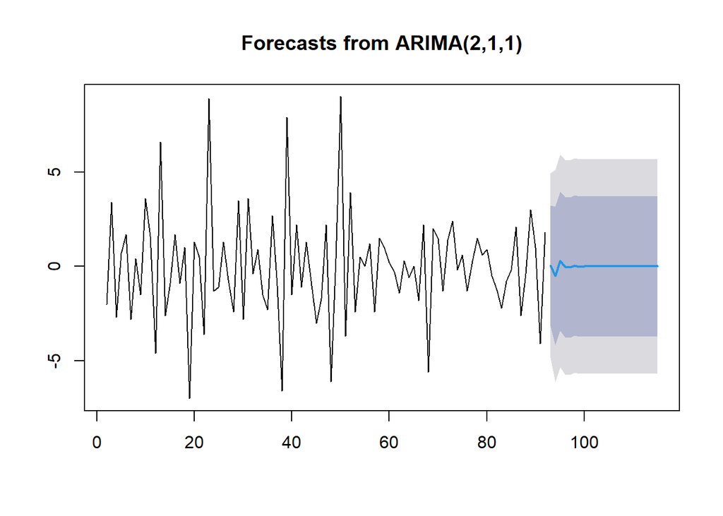

```r
data.ramalan.da <- ramalan.da$mean
plot(ramalan.da)
```

Berdasarkan hasil plot ramalan di atas, dapat dilihat bahwa ramalan ARIMA(2,1,1) fluktuatif di awal, namun selanjutnya cenderung stabil hingga akhir periode. Selanjutnya, dapat dicari nilai akurasi antara hasil ramalan dengan data uji sebagai berikut.

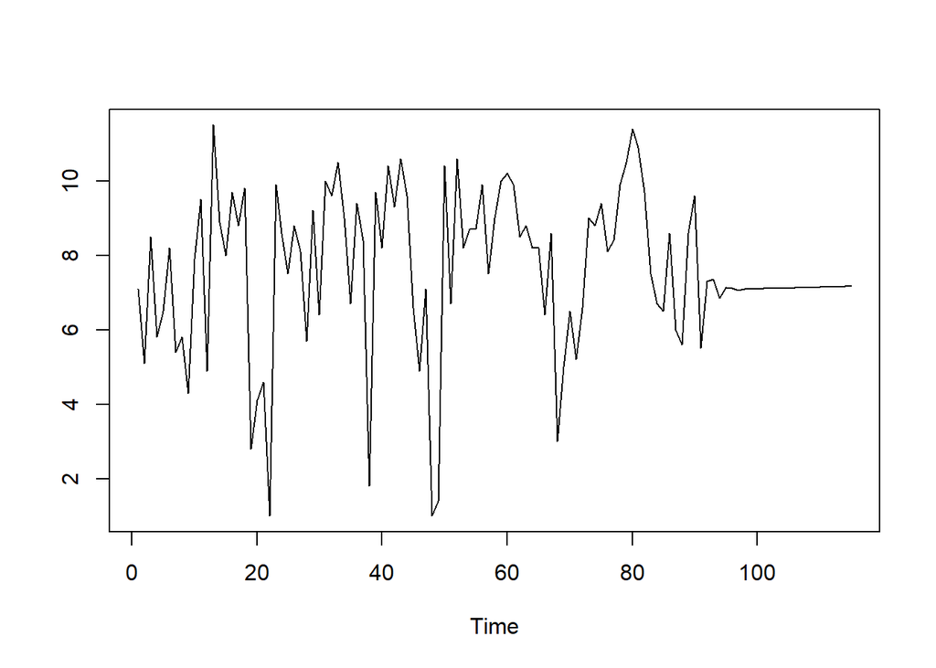

```r
## Invers dari differences
pt_1 <- train.ts[92] #nilai akhir data latih
hasil.forc.Diff <- data.ramalan.da
hasil <- diffinv(hasil.forc.Diff, differences = 1) + pt_1
#has.1 sama hasilnta dengan: cumsum(c(pt_1,hasil.forc.Diff))
ts.plot(train.ts,hasil)
```

```r
perbandingan.da<-matrix(data=c(head(test.ts, n=23), hasil[-1]),
                     nrow = 23, ncol = 2)
colnames(perbandingan.da)<-c("Aktual","Hasil Forecast")
perbandingan.da
```

```
##       Aktual Hasil Forecast
##  [1,]    9.4       7.353424
##  [2,]   10.0       6.845946
##  [3,]    2.3       7.137909
##  [4,]    6.9       7.111012
##  [5,]    8.9       7.056415
##  [6,]    8.0       7.103873
##  [7,]    8.0       7.098815
##  [8,]    7.3       7.097161
##  [9,]    6.8       7.107634
## [10,]    9.6       7.110066
## [11,]    9.3       7.113961
## [12,]    8.6       7.119159
## [13,]    6.8       7.123198
## [14,]    7.2       7.127567
## [15,]   10.0       7.132054
## [16,]    8.6       7.136383
## [17,]    8.8       7.140773
## [18,]    8.8       7.145170
## [19,]    8.0       7.149546
## [20,]    9.9       7.153933
## [21,]    9.0       7.158319
## [22,]    7.5       7.162703
## [23,]    6.4       7.167088
```

```r
accuracy(ts(hasil[-1]), head(test.ts, n=23))
```

```
##                 ME     RMSE      MAE      MPE     MAPE        ACF1 Theil's U
## Test set 0.9672997 1.913729 1.527895 3.433142 23.83877 -0.01046237 0.4571025
```

Diperoleh nilai MAPE sebesar 23.83877. Model ini dikategorikan sebagai model yang lumayan baik karena nilai MAPE > 10 tapi masih berkisar antara 20-35.